# Factor Analysis of IPIP Big Five Personality Data

## The Five-Factor Model of Personality (Big Five)

The Five-Factor Model (FFM), commonly referred to as the “Big Five” is the prevailing empirical taxonomy in contemporary personality psychology. Psychometric research have demonstrated that human personality traits can be comprehensively organized into five broad dimensions. Consequently, each individual can be mathematically represented as a single point within this 5-dimensional continuous space, where their specific coordinates correspond to their standing on each respective trait.

These five latent constructs are:

- **Extraversion:** The tendency to seek stimulation, be outgoing, and engage energetically with the external world.
- **Neuroticism (or Emotional Instability):** The tendency to experience negative emotions, such as anxiety, anger, or depression, and to be highly responsive to stress.
- **Agreeableness:** The tendency to be compassionate, cooperative, and empathetic rather than suspicious or antagonistic towards others.
- **Conscientiousness:** The tendency to display self-discipline, act dutifully, and strive for achievement against measures or outside expectations.
- **Openness to Experience:** The tendency to appreciate art, emotion, adventure, unusual ideas, and variety of experience.

In this analysis, we utilize data from the International Personality Item Pool (IPIP), specifically a 50-item questionnaire designed to measure these five distinct domains. The dataset analyzed here includes responses from around 700 000 participants. Because these psychological constructs are *latent*—meaning they cannot be observed or measured directly—we must infer their presence and magnitude from the observable, self-reported responses to the questionnaire items. To achieve this, we rely on the mathematical framework of Exploratory Factor Analysis.[^1]

## The Mathematical Framework of Exploratory Factor Analysis (EFA)

Exploratory Factor Analysis (EFA) is a multivariate statistical technique utilized to uncover the underlying latent structure of a relatively large set of variables. Unlike Principal Component Analysis (PCA), which is merely a data reduction technique aimed at maximizing explained variance, EFA is a formal causal modeling technique. It assumes that the observed correlations between variables are the result of their shared reliance on a smaller number of unobserved continuous latent variables (the factors). As a first approximation one can see EFA as PCA’s close cousin. In fact it has been shown empirically that results from the PCA and the EFA are often very similar when the communality is sufficiently high.

Let $X_1, X_2, \dots, X_p$ be our $p$ observed variables, which in this context correspond to the $p=50$ individual questions of the survey. We postulate that these variables are standardized (mean zero and variance one). The common factor model asserts that each observed response $X_i$ can be expressed as a linear combination of $m$ underlying latent factors $F_1, F_2, \dots, F_m$ (where $m < p$), plus a unique, unobserved error term $\epsilon_i$. Variable by variable, the model is formulated as:

$$X_i = l_{i1}F_1 + l_{i2}F_2 + \dots + l_{im}F_m + \epsilon_i \quad \text{for} \quad i = 1, \dots, p$$

Here, $l_{ij}$ represents the *factor loading*, which quantifies the direct causal effect (or weight) of the $j$-th latent factor on the $i$-th question.

Equivalently, letting $\mathbf{X} = [X_1, X_2, \dots, X_p]^T$ be the random vector of the standardized observed responses, the model can be expressed in its more compact matrix form:

$$\mathbf{X} = \mathbf{L}\mathbf{F} + \boldsymbol{\epsilon}$$

Where:

- $\mathbf{L}$ is the $p \times m$ matrix of **factor loadings** ($l_{ij}$).
- $\mathbf{F} = [F_1, F_2, \dots, F_m]^T$ contains the **common factors**, which are assumed to have a mean of zero, a variance of one and a correlation matrix $\boldsymbol{\Phi}$.[^2]
- $\boldsymbol{\epsilon} = [\epsilon_1, \epsilon_2, \dots, \epsilon_p]^T$ contains the **unique factors** (comprising both specific variance and measurement error). These are assumed to have a mean of zero and a covariance matrix $\boldsymbol{U^2}$.

A critical assumption of the EFA model is that the unique factors are uncorrelated with each other and with the common factors. Therefore, the *uniqueness matrix* $\boldsymbol{U^2}$ is a diagonal matrix. Under these assumptions, the correlation matrix of the observed variables, denoted as $\boldsymbol{R}$, can be decomposed into two distinct components:

$$\boldsymbol{R} = \mathbf{L}\boldsymbol{\Phi}\mathbf{L}^T + \boldsymbol{U^2}$$

Here, $\mathbf{L}\boldsymbol{\Phi}\mathbf{L}^T$ represents the variance shared among the questions (the *communality*), and $\boldsymbol{U^2}$ represents the variance unique to each specific question. The fundamental objective of EFA is to estimate the matrices $\mathbf{L}$ and $\boldsymbol{U^2}$ given the sample correlation or covariance matrix of $\mathbf{X}$.

## Imports

```r
library(psych)       # factor analysis
library(ggplot2)     # data visualisation
library(pheatmap)    # heatmaps
library(tidyr)       # data reshaping
library(dplyr)       # data manipulation
library(gridExtra)   # combining multiple plots


options(digits = 5)
```

# Data Cleaning

The data file (around 400Mo) can be found on [Kaggle](https://www.kaggle.com/datasets/tunguz/big-five-personality-test).

```r
data_raw <- read.csv("./IPIP-FFM-data-8Nov2018/data-final.csv", sep = "\t", na.strings = c("", " ", "NaN", "NA","NULL"))
```

```r
# Select columns to only keep the 50 items that measure the 5 personality traits.
# See codebook.txt for more details on all the columns.
data <- data_raw[, 1:50]

# Remove rows where IPC != 1, as these could be multiple submissions of the same person.
# The total number of rows in the original dataset is 1 015 341, and 696 845 after cleaning.
cat("Number of lines removed to avoid multiple submission:", sum(data_raw$IPC != 1), "\n")
```

```
Number of lines removed to avoid multiple submission: 318496
```

```r
data <- data[data_raw$IPC == 1, ]

# Remove rows with missing data
n_before <- nrow(data)
data <- data[complete.cases(data), ]
n_after  <- nrow(data)
cat("Number of lines removed to avoid missing data:", n_before - n_after, "\n")
```

```
Number of lines removed to avoid missing data: 1141
```

```r
cat("Number of lines :", n_after)
```

```
Number of lines : 695704
```

```r
data_mat <- as.matrix(data)
head(data)
```

```
  EXT1 EXT2 EXT3 EXT4 EXT5 EXT6 EXT7 EXT8 EXT9 EXT10 EST1 EST2 EST3 EST4 EST5
1    4    1    5    2    5    1    5    2    4     1    1    4    4    2    2
2    3    5    3    4    3    3    2    5    1     5    2    3    4    1    3
3    2    3    4    4    3    2    1    3    2     5    4    4    4    2    2
4    2    2    2    3    4    2    2    4    1     4    3    3    3    2    3
6    3    3    4    2    4    2    2    3    3     4    3    4    3    2    2
7    4    3    4    3    3    3    5    3    4     3    2    4    4    2    4
  EST6 EST7 EST8 EST9 EST10 AGR1 AGR2 AGR3 AGR4 AGR5 AGR6 AGR7 AGR8 AGR9 AGR10
1    2    2    2    3     2    2    5    2    4    2    3    2    4    3     4
2    1    2    1    3     1    1    4    1    5    1    5    3    4    5     3
3    2    2    2    1     3    1    4    1    4    2    4    1    4    4     3
4    2    2    2    4     3    2    4    3    4    2    4    2    4    3     4
6    1    2    1    2     2    2    3    1    4    2    3    2    3    4     4
7    2    2    2    4     4    1    2    1    5    3    5    3    4    4     5
  CSN1 CSN2 CSN3 CSN4 CSN5 CSN6 CSN7 CSN8 CSN9 CSN10 OPN1 OPN2 OPN3 OPN4 OPN5
1    3    4    3    2    2    4    4    2    4     4    5    1    4    1    4
2    3    2    5    3    3    1    3    3    5     3    1    2    4    2    3
3    4    2    2    2    3    3    4    2    4     2    5    1    2    1    4
4    2    4    4    4    1    2    2    3    1     4    4    2    5    2    3
6    3    2    4    1    3    2    4    3    4     3    5    1    5    1    3
7    3    2    4    2    1    4    4    2    2     5    5    2    4    3    4
  OPN6 OPN7 OPN8 OPN9 OPN10
1    1    5    3    4     5
2    1    4    2    5     3
3    2    5    3    4     4
4    1    4    4    3     3
6    1    5    4    5     2
7    1    5    5    4     4
```

```r
# Computing polychoric correlations on large datasets is computationally heavy.
# We check if the matrix has already been saved to avoid recalculating it every time.

pmat_path <- "polychoric_matrix_IPIP-50.rds"

if (file.exists(pmat_path)) {
  cat("Loading saved polychoric matrix...\n")
  poly_mat <- readRDS(pmat_path)
} else {
  cat("Computing polychoric matrix (this may take a while)...\n")
  poly_mat_obj <- polychoric(data_mat, ML=FALSE) #ML=FALSE (default value) to use Olsson's two step procedure
  poly_mat <- poly_mat_obj$rho

  # Save the matrix to a file for future runs
  saveRDS(poly_mat, pmat_path)
  cat("Polychoric matrix saved to", pmat_path, "\n")
}
```

```
Loading saved polychoric matrix...
```

```r
trait_names <- c("Extraversion", "Neuroticism", "Agreeableness",
                 "Conscientiousness", "Openness")
```

# Factor Analysis

## Rotation and Interfactorial Correlations

We apply factor analysis to the data, to extract the Big Five personality traits, with varimax rotation to make the traits more interpretable.

We could have used non-orthogonal rotation methods, like oblimin, which allow for correlated factors. It is commonly recommended to use oblique rotation in psychometric analysis, as said in [Fabrigar et al.(1999)](https://doi.org/10.1037/1082-989X.4.3.272):

> *For many constructs examined in psychology (e.g., mental abilities, personality traits, attitudes), there is substantial theoretical and empirical basis for expecting these constructs (or dimensions of these constructs) to be correlated with one another. Therefore, oblique rotations provide a more accurate and realistic representation of how constructs are likely to be related to one another.*

However, our goal here is not to explain the correlations between factors, but to perform clustering on the factors, and we fear that oblique rotation will deform the space in a way that will influence the clustering. Additionally, [Costello and Osborne(2005)](https://doi.org/10.7275/jyj1-4868) suggest that orthogonal and oblique rotation often produce similar results, so we will not lose much interpretability by using varimax rotation. The results given in alternative B of this notebook agree with this statement.

## Factor Analysis Extraction Method

`psych::fa()` with `fm="minres"` uses the minres method[^3] to perform factor analysis, which does not assume that factors are normally distributed, contrary to the maximum likelihood (ML) method.

Since the assumption that factors follow a Gaussian distribution directly contradicts the assumption of the Gaussian mixture model we will use later, we think it is preferable to use the ULS method instead of the ML method. However, this does not seem to bother [Gerlach, M., Farb, B., Revelle, W. et al.](https://doi.org/10.1038/s41562-018-0419-z), who use the ML method before using GMM. For the sake of comparison, we also perform factor analysis with the ML method in alternative A of this notebook, and the results are very similar to those given by the ULS method.

## How Many Factors to Extract?

```r
# The ULS method has several names: minres, iterated principal factor method,
# or unweighted least squares method.
fa_result <- fa(poly_mat, nfactors = 5, rotate = "varimax", fm = "minres", n.obs = nrow(data_mat), scores="Anderson")

data_fa <- as.data.frame(factor.scores(data_mat, fa_result)$scores)

# Eigenvalues of the original (unreduced) correlation matrix
eigenvalues <- fa_result$values
cat("Eigenvalues:", eigenvalues, "\n")
```

```
Eigenvalues: 7.4533 5.0033 3.6164 3.2961 2.5166 1.5868 0.70334 0.45427 0.34436 0.26689 0.24318 0.22326 0.20283 0.17094 0.13199 0.12306 0.071648 0.04725 0.029906 0.0066417 0.0039356 -0.0069655 -0.028663 -0.045116 -0.046835 -0.071656 -0.080234 -0.080681 -0.097554 -0.1063 -0.11045 -0.11505 -0.12383 -0.…
```

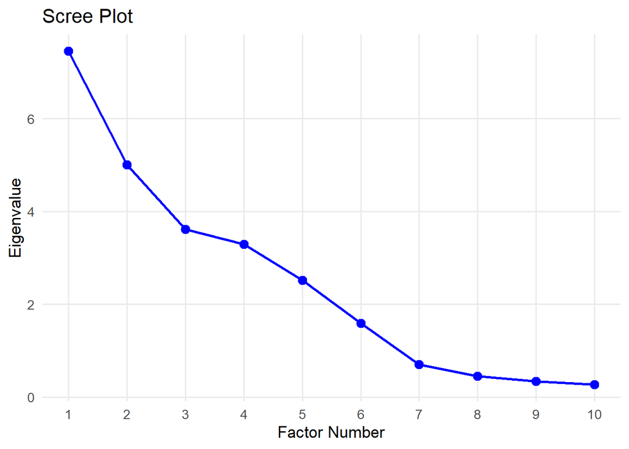

```r
# Plot the ten first eigenvalues in a scree plot
top_10_eigenvalues <- eigenvalues[1:10]
scree_df <- data.frame(factor = 1:10, eigenvalue = top_10_eigenvalues)

ggplot(scree_df, aes(x = factor, y = eigenvalue)) +
  geom_line(color = "blue", linewidth = 1) +
  geom_point(color = "blue", size = 3) +
  scale_x_continuous(breaks = 1:10) +
  labs(title = "Scree Plot", x = "Factor Number", y = "Eigenvalue") +
  theme_minimal(base_size = 13) +
  theme(panel.grid.minor = element_blank())
```

Looking at the scree plot, it is not clear that we should extract five factors; the solution with six factors also seems plausible. We will look at Velicer’s Minimal Average Partial (MAP) criterion, which is commonly considered to be one of the best criterion for choosing how much factor we should extract.

### Velicer’s MAP criterion

Before defining the MAP criterion, we first need to define the partial correlation matrix.

Let $X$ be a centered random vector of dimension $(p + m) \times 1$. We partition $X$ into two subvectors: $X_1$ of dimension $p \times 1$ and $X_2$ of dimension $m \times 1$, such that:

$$X = \begin{bmatrix} X_1 \\ X_2 \end{bmatrix}$$

Let $C:= \text{Cov}(X)$ . Partitioning $C$ conformably with $X$ yields:

$$C = \begin{bmatrix} C_{11} & C_{12} \\ C_{12}^T & C_{22} \end{bmatrix}$$
where $C_{11} = \text{Cov}(X_1)$, $C_{22} = \text{Cov}(X_2)$, and $C_{12} = \text{Cov}(X_1, X_2)$. We assume that $C_{22}$ is nonsingular.

To partial out the effect of $X_2$ from $X_1$, we consider the best linear predictor of $X_1$ based on $X_2$. This is derived from the population linear regression of $X_1$ on $X_2$. The matrix of regression coefficients is given by $C_{12}C_{22}^{-1}$[^4].

We now define the residual vector $e$, which represents the portion of $X_1$ that is orthogonal to (and thus uncorrelated with) the vector space spanned by $X_2$:

$$e = X_1 - C_{12}C_{22}^{-1}X_2$$

The matrix of partial variances and covariances of $X_1$ given $X_2$, denoted $C_{11}^*$, is defined as the covariance matrix of the residual vector $e$. By applying the bilinear properties of the covariance operator, we compute $\text{Cov}(e)$:

$$C_{11}^* = \text{Cov}(X_1 - C_{12}C_{22}^{-1}X_2)$$
$$C_{11}^* = \text{Cov}(X_1) + \text{Cov}(C_{12}C_{22}^{-1}X_2) - \text{Cov}(X_1, C_{12}C_{22}^{-1}X_2) - \text{Cov}(C_{12}C_{22}^{-1}X_2, X_1)$$
Applying the property $\text{Cov}(AY) = A\text{Cov}(Y)A'$ for a constant matrix $A$ and random vector $Y$:

$$C_{11}^* = C_{11} + (C_{12}C_{22}^{-1})\text{Cov}(X_2)(C_{12}C_{22}^{-1})' - \text{Cov}(X_1, X_2)(C_{12}C_{22}^{-1})' - (C_{12}C_{22}^{-1})\text{Cov}(X_2, X_1)$$
Substitute the block matrices $C_{22} = \text{Cov}(X_2)$ and $C_{12} = \text{Cov}(X_1, X_2)$. Note that $\text{Cov}(X_2, X_1) = C_{12}'$ and $(C_{22}^{-1})' = C_{22}^{-1}$ due to symmetry:

$$C_{11}^* = C_{11} + C_{12}C_{22}^{-1}C_{22}C_{22}^{-1}C_{12}' - C_{12}C_{22}^{-1}C_{12}' - C_{12}C_{22}^{-1}C_{12}'$$
Since $C_{22}C_{22}^{-1} = I$, the expression simplifies to:

$$C_{11}^* = C_{11} + C_{12}C_{22}^{-1}C_{12}' - 2C_{12}C_{22}^{-1}C_{12}'$$
$$C_{11}^* = C_{11} - C_{12}C_{22}^{-1}C_{12}'$$

A correlation matrix is derived by scaling a covariance matrix by the inverse of the standard deviations of its variables. Let $D$ be a diagonal matrix containing the main diagonal elements of the partial covariance matrix $C_{11}^*$:

$$D = \text{Diag}(C_{11}^*)$$
The diagonal elements of $D$ are the partial variances. Consequently, $D^{-1/2}$ is a diagonal matrix containing the reciprocals of the partial standard deviations. Pre-multiplying and post-multiplying $C_{11}^*$ by this matrix standardizes the partial covariances, yielding the partial correlation matrix $R_{11}^*$:

$$R_{11}^* = D^{-1/2}C_{11}^*D^{-1/2}$$
Substituting the derived expression for $C_{11}^*$, we obtain $R_{11}^* = D^{-1/2}(C_{11} - C_{12}C_{22}^{-1}C_{12}')D^{-1/2}$.

To connect the general partial correlation framework to the EFA model, the notations translate as follows:

- $X_1 \equiv \mathbf{X}$: The vector of observed variables.
- $X_2 \equiv \mathbf{F}$: The vector of latent factors (or extracted principal components).
- $C^*_{11} \equiv \boldsymbol{U^2}$: The residual covariance matrix corresponds to the diagonal uniqueness matrix.
- $R^*_{11} \equiv \mathbf{I}$ (Theoretically): The partial correlation matrix of the observed variables after partialling out the factors. As the standardized version of the diagonal $\boldsymbol{U^2}$ matrix, a perfectly specified theoretical model yields the identity matrix.

The Minimum Average Partial (MAP) criterion is just the sum of squared off diagonal elements of the *empirical* partial correlation matrix $\hat{R}_{11}^*$, denoted here by $f_m$. It is supposed to be minimal when the number of extracted factors $m$ attains its optimal values.

Here is another explanation of the rational behind this criterion from [Velicer’s original 1976 paper](https://doi.org/10.1007/BF02293557):

> In order to better understand why the value $f_m$ first decreases and then increases, consider the general form of a partial correlation equation
> $$\begin{equation*}
> r_{i j, y}=\frac{r_{i j}-r_{j y} r_{i y}}{\left(\left(1-r_{j y}{ }^2\right)\left(1-r_{i y}{ }^2\right)\right)^{1 / 2}}
> \end{equation*}$$
> where $i, j$ represent any two of the $p$ observed variables and $y$ represents a [factor]. With no loss of generality, we assume $r_{i j}, r_{i j}$, and $r_{i y}$ to be positive. The value of the partial correlation will decrease as long as the numerator decreases faster than the denominator. The value of the partial correlation will increase whenever the reverse is true; for example, when $r_{iy}$ is large and $r_{j y}$ is small. *Such a situation would occur if a [factor] has a high correlation with only one variable and near zero correlations with the others (commonly referred to as a “specific”)*. This explanation can be extended inductively to the case where more than one [factor] has been extracted by using $k$-th order partials calculated from ( $k-1$-th) order partials. Using this stopping rule, the first $m$ [factors] could be referred to as “common [factors]”. We would expect that two or more variables would have “high” loadings on these [factors]. The remaining $m+1$ to $p$ [factors] may include some that have adequate reliability. However, these will be “unique” [factors] (i.e., having “high” loadings on only one of the original variables).

In other terms, as you extract “common factors” (which relate to multiple variables), the remaining correlations between those variables successfully decrease. But if you extract a “unique factor” (which relates strongly to only *one* variable), the mathematical formula shrinks the denominator more than the numerator, which artificially inflates the remaining correlations. Therefore, the overall value $f_m$ drops while you are finding useful common factors, and starts to rise as soon as you begin extracting factors specific to single variables.

### Very Simple Structure criterion

Most people, when interpreting a factor solution, will highlight the large (salient) loadings and ignore the small loadings. That is, they are interpreting the factor matrix as if it had simple structure. How well does this simplified matrix reproduce the original matrix ? To quantify this, let $c$ be the complexity (number of non zero loadings) of an item and $max_c$ be the greatest (absolute) $c$ loadings for an item, then find the Very Simple Structure matrix, $\hat{\mathbf{S}}_c$, where
$$\hat{s}_{cij} = \begin{cases} \hat{l}_{ij} & \text{if } \hat{l}_{ij} \in max_c(\hat{l}_{i.}) \\ 0 & \text{otherwise} \end{cases}$$
Then let
$$\hat{\mathbf{R}}_{sc}^* = \hat{\mathbf{R}} - \hat{\mathbf{S}}_c\hat{\mathbf{S}}_c^T$$
and
$$VSS_c = 1 - \frac{\mathbf{1}{\hat{\mathbf{R}}_{sc}^{*\odot 2}}\mathbf{1}' - tr(\hat{\mathbf{R}}_{sc}^*)}{\mathbf{1}\hat{\mathbf{R}}^{\odot 2}\mathbf{1}' - tr(\hat{\mathbf{R}})}$$
The VSS criterion for a complexity $c$ is 1 - the squared residual correlations divided by the squared observed correlations, where the residuals are found by the “simplified” factor equation $\hat{\mathbf{R}}_{sc}^* = \hat{\mathbf{R}} - \hat{\mathbf{S}}_c\hat{\mathbf{S}}_c^T$. [^5]

The VSS criterion is less used than the MAP in the literature. In fact the VSS criterion makes the strong assumption that the loadings of variable on factors are simple, which is not always the case. Our personal preference goes to the MAP criterion, which seems more objective.

Here are now the results of both MAP and VSS criterion.

```r
# Run MAP and VSS test on the polychoric correlation matrix
n_of_factors_diagnostic <- VSS(poly_mat, n.obs = nrow(data_mat), n = 10, plot = FALSE)
summary(n_of_factors_diagnostic)
```

```
Very Simple Structure
VSS complexity 1 achieves a maximimum of 0.65  with  6  factors
VSS complexity 2 achieves a maximimum of 0.8  with  5  factors

The Velicer MAP criterion achieves a minimum of 0.03  with  6  factors
```

The MAP criterion advises us to extract six factors. In fact six factor model have largely been discussed in the literature, such as the HEXACO, which is more or less the Big 5 with the addition of a honesty-humility trait. However, since our data have been specifically designed to estimate the Big 5 model, we will stick to a five factor model here.

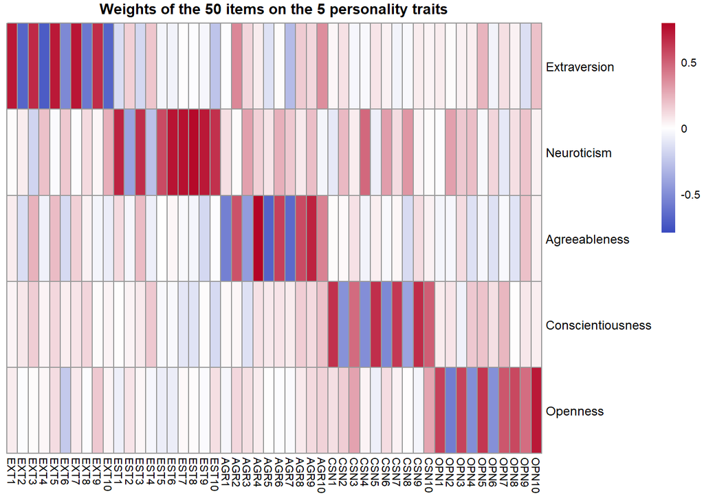

```r
# Plot the loadings of the 50 items on the 5 personality traits as a heatmap.
# NOTE: The factor order below is inferred by inspecting which group of items
# loads most strongly on each factor (see the loading heatmap).

data_fa  <- data_fa[, c(2,1,3,5,4)]
fa_result$loadings <- fa_result$loadings[, c(2,1,3,5,4)]

# fa$loadings is items × factors; transpose to get traits × items
weights <- t(as.matrix(fa_result$loadings))


rownames(weights) <- trait_names

coolwarm <- colorRampPalette(c("#3B4CC0", "white", "#B40426"))(200)
lim      <- max(abs(weights))
breaks   <- seq(-lim, lim, length.out = 201)

pheatmap(
  weights,
  color        = coolwarm,
  breaks       = breaks,
  cluster_rows = FALSE,
  cluster_cols = FALSE,
  main         = "Weights of the 50 items on the 5 personality traits",
  fontsize      = 8,
  fontsize_row  = 9
)
```

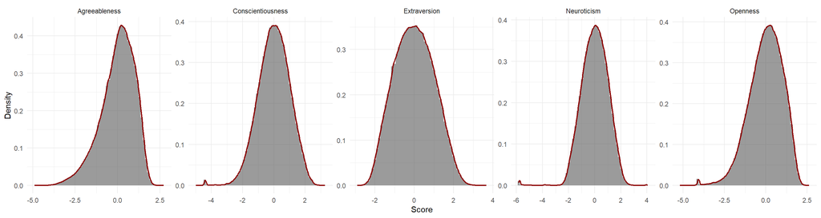

```r
# From the previous plot, we can infer that factors are ordered as listed in trait_names.
# Assign the Big Five trait names as column names.
colnames(data_fa) <- trait_names


data_fa_long <- pivot_longer(data_fa, cols = everything(),
                             names_to = "trait", values_to = "score")
data_fa_long$trait <- factor(data_fa_long$trait)

ggplot(data_fa_long, aes(x = score)) +
  geom_histogram(aes(y = after_stat(density)), bins = 60, alpha = 0.6, color = NA) +
  geom_density(color = "darkred", linewidth = 0.8) +
  facet_wrap(~trait, nrow = 1, scales = "free") +
  theme_minimal(base_size = 11) +
  labs(x = "Score", y = "Density")
```

```r
write.csv(data_fa, "IPIP-50_FFM_factor_scores.csv", row.names = FALSE)
```

# Alternative A: Comparison of ULS vs ML Extraction Methods for Factor Analysis

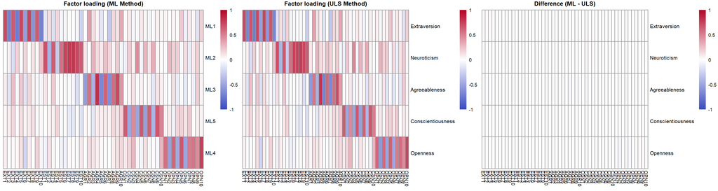

```r
# Perform factor analysis with the maximum likelihood (ML) method,
# for comparison with the ULS method.
fa_ml     <- fa(poly_mat, nfactors = 5, rotate = "varimax", fm = "ml", n.obs = nrow(data_mat))
data_fa_ml <- as.data.frame(factor.scores(data_mat, fa_ml)$scores)

# Exchange column to properly match with traits
data_fa_ml  <- data_fa_ml[, c(1, 2, 3, 5, 4)]
fa_ml$loadings <- fa_ml$loadings[, c(1, 2, 3, 5, 4)]

colnames(data_fa_ml) <- trait_names
loadings_ml <- as.matrix(fa_ml$loadings)

weights_ml <- t(loadings_ml)

# Loading matrix comparison plots
breaks_full <- seq(-1, 1, length.out = 201)

p1 <- pheatmap(weights_ml, color = coolwarm, breaks = breaks_full,
               cluster_rows = FALSE, cluster_cols = FALSE,
               main = "Factor loading (ML Method)",
               fontsize = 7, fontsize_row = 8, silent = TRUE)
p2 <- pheatmap(weights,    color = coolwarm, breaks = breaks_full,
               cluster_rows = FALSE, cluster_cols = FALSE,
               main = "Factor loading (ULS Method)",
               fontsize = 7, fontsize_row = 8, silent = TRUE)
diff_ml <- unclass(weights)- unclass(weights_ml) #unclass to avoid the rounding of "loadings" class
p3 <- pheatmap(diff_ml,    color = coolwarm, breaks = breaks_full,
               cluster_rows = FALSE, cluster_cols = FALSE,
               main = "Difference (ML - ULS)",
               fontsize = 7, fontsize_row = 8, silent = TRUE)

grid.arrange(p1$gtable, p2$gtable, p3$gtable, ncol = 3,
             widths = c(1, 1, 1))
```

```r
cat("Difference between the loadings of the ML method and the ULS method:\n")
```

```
Difference between the loadings of the ML method and the ULS method:
```

```r
diff_ml
```

```
                        EXT1       EXT2        EXT3       EXT4       EXT5
Extraversion       0.0083057  0.0115442  1.0751e-02  0.0105003  0.0028835
Neuroticism        0.0029732  0.0052782  4.7234e-03  0.0104872  0.0052720
Agreeableness     -0.0131482 -0.0156341 -1.4987e-02 -0.0165491 -0.0071764
Conscientiousness -0.0016847  0.0062726 -7.0566e-05  0.0086902 -0.0012566
Openness          -0.0111956 -0.0101243 -8.9614e-03 -0.0080103 -0.0041271
                        EXT6       EXT7       EXT8        EXT9      EXT10
Extraversion       0.0161026  0.0029172  0.0089130  0.01425740  0.0164277
Neuroticism        0.0066705  0.0039971  0.0086318  0.00368265  0.0097061
Agreeableness     -0.0223750 -0.0113589 -0.0097635 -0.01995981 -0.0146076
Conscientiousness  0.0037210 -0.0013104  0.0055263 -0.00061461  0.0086081
Openness          -0.0137756 -0.0076631 -0.0066903 -0.00669032 -0.0093560
                        EST1       EST2       EST3       EST4       EST5
Extraversion      -0.0056712  0.0207413 -0.0014613  0.0176111  0.0028331
Neuroticism        0.0080909  0.0176453  0.0163005  0.0115949  0.0015532
Agreeableness      0.0086743 -0.0296083  0.0036651 -0.0241067 -0.0060286
Conscientiousness  0.0013880  0.0037306  0.0076339 -0.0020539  0.0014604
Openness           0.0043935 -0.0202379  0.0059023 -0.0180758 -0.0079952
                         EST6        EST7        EST8        EST9       EST10
Extraversion      -0.00146104 -0.00702127 -0.00709721 -0.00073367 -8.8442e-03
Neuroticism       -0.00230324 -0.02436254 -0.02058780 -0.00437835 -8.4727e-06
Agreeableness      0.00067802  0.00086254  0.00093219 -0.00360592  3.7091e-03
Conscientiousness  0.00142306  0.00442093  0.00384661  0.00143777  3.8112e-03
Openness          -0.00093933 -0.00228726 -0.00059238  0.00068110  8.1298e-03
                        AGR1        AGR2        AGR3       AGR4        AGR5
Extraversion       0.0068747  0.00619308  0.00652507  0.0139494  7.8400e-03
Neuroticism       -0.0017829  0.01056523  0.00327941  0.0122746  1.4661e-03
Agreeableness     -0.0121130 -0.00720708 -0.01484227 -0.0214462 -2.1829e-02
Conscientiousness -0.0021667  0.00465124  0.00060057  0.0087951 -2.3066e-05
Openness          -0.0157326 -0.00010481 -0.00445853 -0.0036083 -1.3749e-02
                        AGR6       AGR7       AGR8       AGR9      AGR10
Extraversion       0.0136642  0.0085953  0.0106641  0.0155899  0.0104936
Neuroticism        0.0093919  0.0020234  0.0115263  0.0086549  0.0073637
Agreeableness     -0.0190392 -0.0303240 -0.0128588 -0.0287891 -0.0170745
Conscientiousness  0.0071042  0.0029381  0.0073078  0.0090290  0.0049522
Openness          -0.0120852 -0.0121053 -0.0063222 -0.0065323 -0.0143783
                         CSN1       CSN2        CSN3       CSN4        CSN5
Extraversion       0.00430612  0.0150068  0.00690532  0.0135919  0.00225520
Neuroticism       -0.00362899  0.0208468  0.00354325  0.0190052 -0.00964183
Agreeableness     -0.00326076 -0.0200741 -0.00873876 -0.0216281 -0.00574855
Conscientiousness -0.00073473  0.0086189  0.00754581  0.0021255 -0.00084658
Openness          -0.00054522 -0.0070089 -0.00046508 -0.0077722 -0.01018927
                        CSN6        CSN7       CSN8       CSN9      CSN10
Extraversion       0.0160336  0.00272102  0.0102221  0.0053045  0.0075071
Neuroticism        0.0201296  0.00062705  0.0089329 -0.0004101  0.0041225
Agreeableness     -0.0210654 -0.00171419 -0.0212416 -0.0047424 -0.0047388
Conscientiousness  0.0046417  0.00088043  0.0076689 -0.0030531  0.0060856
Openness          -0.0127010  0.00112584 -0.0115639 -0.0051600 -0.0030698
                        OPN1       OPN2       OPN3       OPN4       OPN5
Extraversion       0.0024460  0.0179937  0.0062370  0.0183774  0.0118436
Neuroticism        0.0080229  0.0142297  0.0028323  0.0103226  0.0053227
Agreeableness     -0.0087366 -0.0205917 -0.0034214 -0.0255719 -0.0068723
Conscientiousness  0.0050448  0.0040837  0.0039640  0.0029642  0.0032417
Openness           0.0282043 -0.0348169 -0.0142979 -0.0265531 -0.0332200
                        OPN6       OPN7       OPN8       OPN9      OPN10
Extraversion       0.0072254  0.0083674  0.0028012  0.0047411  0.0084230
Neuroticism        0.0047008  0.0021057  0.0057278  0.0080299  0.0058342
Agreeableness     -0.0209224 -0.0142542 -0.0109625 -0.0035503 -0.0012663
Conscientiousness -0.0013243  0.0062281  0.0055354  0.0066786  0.0036745
Openness           0.0094418  0.0023395  0.0247927  0.0024562 -0.0250617
```

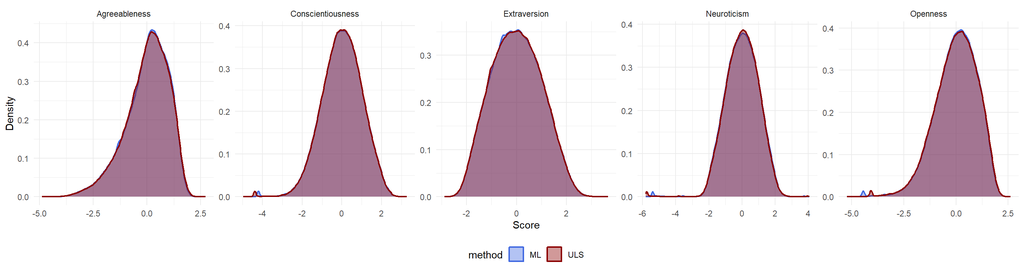

```r
# Histogram comparison: ML vs ULS distributions for each trait

data_compare <- bind_rows(
  pivot_longer(data_fa_ml, cols = everything(),
               names_to = "trait", values_to = "score") %>%
    mutate(method = "ML"),
  pivot_longer(data_fa, cols = everything(),
               names_to = "trait", values_to = "score") %>%
    mutate(method = "ULS")
)
data_compare$trait <- factor(data_compare$trait)

ggplot(data_compare, aes(x = score, color = method, fill = method)) +

  geom_density(alpha = 0.4, linewidth = 0.8) +

  facet_wrap(~trait, nrow = 1, scales = "free") +

  scale_fill_manual(values  = c("ML" = "royalblue", "ULS" = "darkred")) +
  scale_color_manual(values = c("ML" = "royalblue", "ULS" = "darkred")) +

  theme_minimal(base_size = 11) +
  theme(legend.position = "bottom") +
  labs(x = "Score", y = "Density")
```

We can see that the loadings and distributions of the factors with the ULS method are very similar to those given by the factor analysis with the ML method, which suggests that the choice of extraction method does not have a strong influence on the results. However, we think it is preferable to use the ULS method, since it does not assume that factors are normally distributed, which is more consistent with the assumptions of the Gaussian mixture model we will use later.

# Alternative B: Comparison of Varimax vs Oblimin Rotation Methods for Factor Analysis

In the main part of the notebook, we use orthogonal rotation (varimax) to make the factors more interpretable. However, we could have used oblique (oblimin) rotation, which allows for correlated factors. We will see that the results given by the oblimin rotation are very similar to those given by the varimax rotation, which suggests that the choice of rotation method does not have a strong influence on the results.

```r
# Perform factor analysis with the oblimin rotation method,
# for comparison with the varimax rotation used above.
# scores="tenBerge" to preserve correlation
fa_obli      <- fa(poly_mat, nfactors = 5, rotate = "oblimin", fm = "minres", n.obs = nrow(data_mat), scores="tenBerge")
data_fa_obli <- as.data.frame(factor.scores(data_mat, fa_obli)$scores)
```

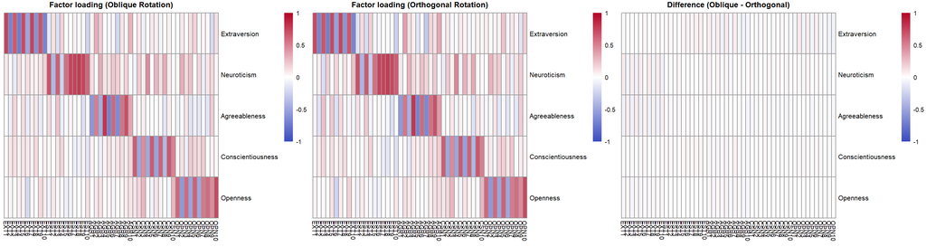

```r
# Exchange column to properly match with traits
data_fa_obli  <- data_fa_obli[, c(1, 2, 3, 5, 4)]
fa_obli$loadings <- fa_obli$loadings[, c(1, 2, 3, 5, 4)]

# From our (not shown) observations, factors are ordered as follows:
colnames(data_fa_obli) <- trait_names

loadings_obli  <- as.matrix(fa_obli$loadings)

weights_obli <- t(loadings_obli)
rownames(weights_obli) <- trait_names

# Loading matrix comparison plots
p_obli <- pheatmap(weights_obli, color = coolwarm, breaks = breaks_full,
                   cluster_rows = FALSE, cluster_cols = FALSE,
                   main = "Factor loading (Oblique Rotation)",
                   fontsize = 7, fontsize_row = 8, silent = TRUE)
p_vari <- pheatmap(weights,      color = coolwarm, breaks = breaks_full,
                   cluster_rows = FALSE, cluster_cols = FALSE,
                   main = "Factor loading (Orthogonal Rotation)",
                   fontsize = 7, fontsize_row = 8, silent = TRUE)
diff_obli <- unclass(weights_obli) - unclass(weights)
p_diff <- pheatmap(diff_obli,   color = coolwarm, breaks = breaks_full,
                   cluster_rows = FALSE, cluster_cols = FALSE,
                   main = "Difference (Oblique - Orthogonal)",
                   fontsize = 7, fontsize_row = 8, silent = TRUE)

grid.arrange(p_obli$gtable, p_vari$gtable, p_diff$gtable, ncol = 3,
             widths = c(1, 1, 1))
```

## Correlation Between the Factors Obtained with the Oblimin Rotation

Unlike the factors obtained with the varimax rotation, the factors obtained with the oblimin rotation are correlated, as expected. However, the correlations between factors are not very strong, which suggests that the factors are still relatively independent from each other. This is consistent with the fact that the results given by the oblimin rotation are very similar to those given by the varimax rotation. We give here a comparison of the correlation matrix we found with the one given by Van der Linden et al. in their [2010 meta-analysis](https://doi.org/10.1016/j.jrp.2010.03.003).

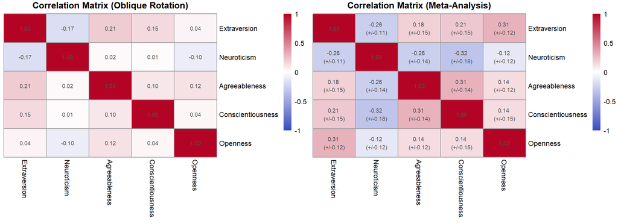

```r
# Correlation matrix of the 5 personality traits obtained with the oblique rotation
corr_obli <- fa_obli$Phi

rownames(corr_obli) <- colnames(corr_obli) <- trait_names

# (Uncorrected) correlation matrix from the meta-analysis of Van der Linden et al. (2010)
corr_meta <- matrix(c(
   1.00, -0.26,  0.18,  0.21,  0.31,
  -0.26,  1.00, -0.26, -0.32, -0.12,
   0.18, -0.26,  1.00,  0.31,  0.14,
   0.21, -0.32,  0.31,  1.00,  0.14,
   0.31, -0.12,  0.14,  0.14,  1.00
), nrow = 5, byrow = TRUE,
   dimnames = list(trait_names, trait_names))

sd_meta <- matrix(c(
  0.00, 0.11, 0.15, 0.15, 0.12,
  0.11, 0.00, 0.14, 0.18, 0.12,
  0.15, 0.14, 0.00, 0.14, 0.12,
  0.15, 0.18, 0.14, 0.00, 0.15,
  0.12, 0.12, 0.12, 0.15, 0.00
), nrow = 5, byrow = TRUE)

# Build annotation matrices
annot_obli <- matrix(sprintf("%.2f", corr_obli), nrow = 5,
                     dimnames = dimnames(corr_obli))
annot_meta <- matrix("", nrow = 5, ncol = 5, dimnames = dimnames(corr_meta))
for (i in 1:5) {
  for (j in 1:5) {
    if (i == j) {
      annot_meta[i, j] <- sprintf("%.2f", corr_meta[i, j])
    } else {
      annot_meta[i, j] <- sprintf("%.2f \n(+/-%.2f)", corr_meta[i, j], sd_meta[i, j])
    }
  }
}

# Show the two correlation matrices side by side for comparison
p_corr_obli <- pheatmap(
  corr_obli, color = coolwarm, breaks = breaks_full,
  cluster_rows = FALSE, cluster_cols = FALSE,
  display_numbers = annot_obli, number_format = "%.2f",
  main = "Correlation Matrix (Oblique Rotation)",
  fontsize = 9, silent = TRUE
)
p_corr_meta <- pheatmap(
  corr_meta, color = coolwarm, breaks = breaks_full,
  cluster_rows = FALSE, cluster_cols = FALSE,
  display_numbers = annot_meta,
  main = "Correlation Matrix (Meta-Analysis)",
  fontsize = 9, silent = TRUE
)

grid.arrange(p_corr_obli$gtable, p_corr_meta$gtable, ncol = 2,
             widths = c(1, 1))
```

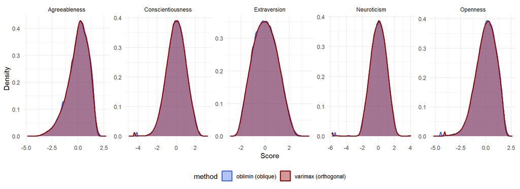

```r
# Histogram comparison: oblimin vs varimax distributions for each trait
data_compare_obli <- bind_rows(
  pivot_longer(data_fa_obli, cols = everything(),
               names_to = "trait", values_to = "score") %>%
    mutate(method = "oblimin (oblique)"),
  pivot_longer(data_fa, cols = everything(),
               names_to = "trait", values_to = "score") %>%
    mutate(method = "varimax (orthogonal)")
)
data_compare_obli$trait <- factor(data_compare_obli$trait)

ggplot(data_compare_obli, aes(x = score, color = method, fill = method)) +

  geom_density(alpha = 0.4, linewidth = 0.8) +

  facet_wrap(~trait, nrow = 1, scales = "free") +

  scale_fill_manual(values  = c("oblimin (oblique)" = "royalblue", "varimax (orthogonal)" = "darkred")) +
  scale_color_manual(values = c("oblimin (oblique)" = "royalblue", "varimax (orthogonal)" = "darkred")) +

  theme_minimal(base_size = 11) +
  theme(legend.position = "bottom") +
  labs(x = "Score", y = "Density")
```

# Alternative C: Pearson vs polychoric matrix for factor extraction

## Polychoric correlation matrix

### The trouble with Likert scales

Exploratory factor analysis is based on a correlation matrix: from a correlation matrix, it infers the underlying factors that explain the correlations between the items. The core assumption of our study is that the responses to the questionnaire are strongly determined by some underlying *continuous* factors. So it seems intuitive that each person has an “internal” *continuous* response to each question that is a linear combination of the underlying (continuous) factors plus a random noise. This “internal” response is then discretized into an ordinal Likert scale when answering the questionnaire. In a perfect world, we would have direct access to these “internal” continuous responses, which are more reflective of the personality of the participant, and then we would perform the factor analysis on the correlations of these “internal” continuous responses. But we only have access to the Likert scales, which correlation underestimate the “true” underlying correlation, as we can see in the following theorem:

> **Theorem:** If $(Z_1, Z_2)$ have a joint bivariate normal distribution with correlation coefficient $\rho$, then for any Borel-measurable functions $f$ and $g$ such that $f(Z_1)$ and $g(Z_2)$ possess finite variances, the absolute correlation between the transformed variables is bounded by the absolute value of $\rho$:
> $$|\text{corr}(f(Z_1), g(Z_2))| \leq |\rho|$$
> The equality only happens when $f=g=id$.

> **Proof:** The proof rely on the fact that we can express $L^2$ random variables (w.r.t. Gaussian measure) as series of standardized Hermite-Tchebycheff polynomial, which are orthogonal w.r.t. Gaussian measure. See [H.O. Lancaster(1957)](https://doi.org/10.2307/2333274) for the full proof.

Now if we assume that $Z_1$ and $Z_2$ are Gaussian, we can define $L_1$ and $L_2$ as the observed ordinal Likert variables. These discrete variables are created by partitioning the continuous variables $Z_1$ and $Z_2$ using a set of thresholds (e.g., $L_1 = i$ if $\alpha_{i-1} < Z_1 \leq \alpha_i$, and $L_2 = j$ if $\beta_{j-1} < Z_2 \leq \beta_j$). Since $L_1$ and $L_2$ are created through step functions of the underlying continuous variables (i.e., $L_1 = f(Z_1)$ and $L_2 = g(Z_2)$), it rigorously follows that the correlation between the discrete responses is strictly bounded by the correlation of the “internal” continuous variables:

$$|\text{corr}(L_1, L_2)| < |\rho|$$

This is why Likert-scale questionnaires tend to underestimate the “true” correlation between the questions. From this example, it seems very plausible that the naive use of Pearson correlation on Likert scale can give poor results. One way of addressing this issue is to use a polychoric correlation matrix.

### Polychoric correlation estimation

Given what we have said above, if we use the Pearson correlation matrix, we will obtain an estimation of the correlation of the Likert discrete variables, not the correlation of the underlying continuous ones. So we need a way to infer the correlation of the underlying continuous variables given their discretized versions. This is exactly what polychoric correlation is supposed to do.

To compute the polychoric correlation, we assume that the underlying continuous latent variables $(Z_1, Z_2)$ follow a standard bivariate normal distribution with correlation $\rho$. The theoretical probability $\pi_{ij}$ of an observation falling into the $i$-th category for $L_1$ and the $j$-th category for $L_2$ is the following:

$$\pi_{ij} = \Phi_2^{}(\alpha_i, \beta_j; \rho) - \Phi_2(\alpha_{i-1}, \beta_j; \rho) - \Phi_2(\alpha_i, \beta_{j-1}; \rho) + \Phi_2(\alpha_{i-1}, \beta_{j-1}; \rho)$$

where $\Phi_2$ is the cumulative distribution function (CDF) of the standard bivariate normal distribution.

To estimate these parameters from an observed dataset where $n_{ij}$ represents the frequency of responses in cell $(i, j)$, we use Maximum Likelihood Estimation (MLE). The log-likelihood function to maximize is defined as:

$$\ell(\rho, \mathbf{\alpha}, \mathbf{\beta}) = \sum_{i} \sum_{j} n_{ij} \ln[\pi_{ij}(\rho, \alpha, \beta)]$$

**Olsson’s Two-Step Method** Maximizing this log-likelihood for all parameters ($\rho$, $\alpha$, $\beta$) simultaneously is computationally expensive. To solve this, the standard approach relies on [Olsson’s (1979)](https://doi.org/10.1007/BF02296207) two-step procedure, which consists of first estimating the thresholds $\alpha$ and $\beta$ using only the marginal distributions, and then estimating the correlation coefficient $\rho$. Despite the theoretical non-optimality of this procedure, the gain in computational efficiency outweighs the loss in precision, as reported in Olsson’s article. However, it is still possible to use a full maximum likelihood estimation for maximum statistical efficiency. In this code, we will use Olsson’s two step method (parameter `ML=FALSE` in the `polychoric` function from `psych` package).

### Empirical evidence of the superiority of polychoric correlation matrix in EFA

The methodological importance of this choice is highlighted by [Holgado–Tello et al (2008)](https://doi.org/10.1007/s11135-008-9190-y). The authors demonstrate that when data are ordinal, polychoric correlations provide a more accurate and stable reproduction of the original factor structure compared to Pearson correlations, which can lead to biased loadings and incorrect factor counts.

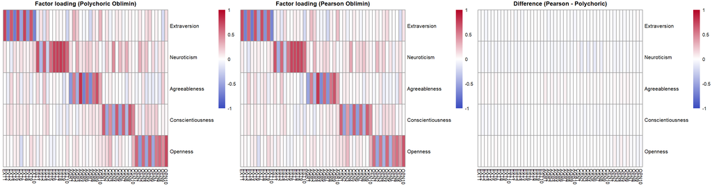

```r
# Perform factor analysis with the oblimin rotation method using Pearson correlations.
# NOTE: The default was set to polychoric at the beginning of the notebook for all main analyses.
fa_pearson      <- fa(data_mat, nfactors = 5, rotate = "oblimin", fm = "minres",
                   cor = "cor", scores="tenBerge")
data_fa_pearson <- as.data.frame(fa_pearson$scores)
loadings_pearson  <- as.matrix(fa_pearson$loadings)

# Apply the trait names to the columns and rows
colnames(data_fa_pearson) <- trait_names

weights_pearson <- t(loadings_pearson)
rownames(weights_pearson) <- trait_names

# Loading matrix comparison plots
p_poly <- pheatmap(weights_obli, color = coolwarm, breaks = breaks_full,
                   cluster_rows = FALSE, cluster_cols = FALSE,
                   main = "Factor loading (Polychoric Oblimin)",
                   fontsize = 7, fontsize_row = 8, silent = TRUE)

p_pearson <- pheatmap(weights_pearson, color = coolwarm, breaks = breaks_full,
                   cluster_rows = FALSE, cluster_cols = FALSE,
                   main = "Factor loading (Pearson Oblimin)",
                   fontsize = 7, fontsize_row = 8, silent = TRUE)

# Calculate difference using unclass() to prevent the "loadings" rounding issue
diff_pearson <- unclass(weights_pearson) - unclass(weights_obli)

p_diff <- pheatmap(diff_pearson,   color = coolwarm, breaks = breaks_full,
                   cluster_rows = FALSE, cluster_cols = FALSE,
                   main = "Difference (Pearson - Polychoric)",
                   fontsize = 7, fontsize_row = 8, silent = TRUE)

grid.arrange(p_poly$gtable, p_pearson$gtable, p_diff$gtable, ncol = 3,
             widths = c(1, 1, 1))
```

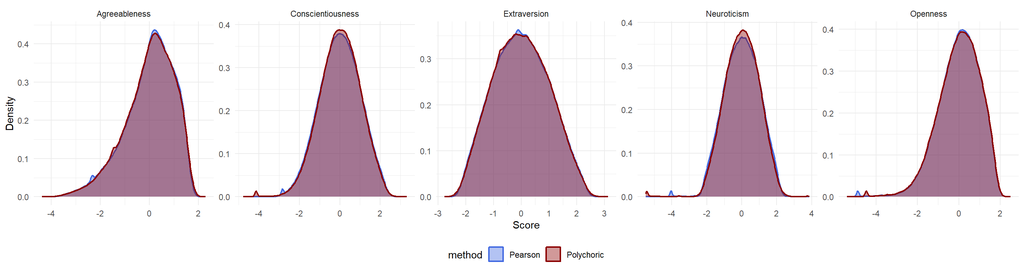

```r
# Histogram comparison: Pearson vs Polychoric correlation matrix for factor analysis for each trait

data_compare_pearson <- bind_rows(
  pivot_longer(data_fa_pearson, cols = everything(),
               names_to = "trait", values_to = "score") %>%
    mutate(method = "Pearson"),
  pivot_longer(data_fa_obli, cols = everything(),
               names_to = "trait", values_to = "score") %>%
    mutate(method = "Polychoric")
)

# Convert trait to factor to control facet order if needed
data_compare_pearson$trait <- factor(data_compare_pearson$trait)

ggplot(data_compare_pearson, aes(x = score, color = method, fill = method)) +

  geom_density(alpha = 0.4, linewidth = 0.8) +

  facet_wrap(~trait, nrow = 1, scales = "free") +

  scale_fill_manual(values  = c("Pearson" = "royalblue", "Polychoric" = "darkred")) +
  scale_color_manual(values = c("Pearson" = "royalblue", "Polychoric" = "darkred")) +

  theme_minimal(base_size = 11) +
  theme(legend.position = "bottom") +
  labs(x = "Score", y = "Density")
```

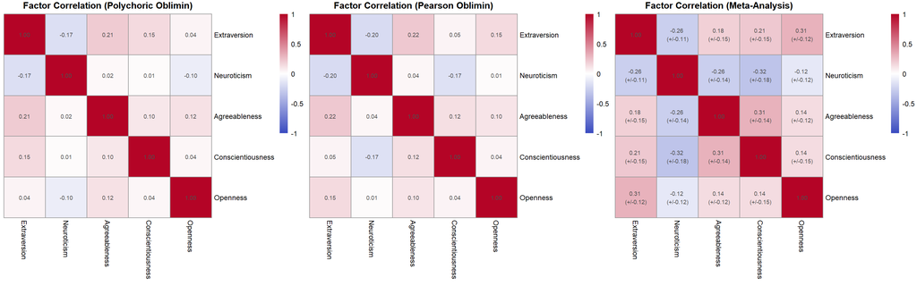

```r
corr_poly <- fa_obli$Phi

corr_pearson <- fa_pearson$Phi

annot_poly <- matrix(sprintf("%.2f", corr_poly), nrow = 5)
annot_pearson <- matrix(sprintf("%.2f", corr_pearson), nrow = 5)

rownames(corr_poly) <- colnames(corr_poly) <- trait_names
rownames(corr_pearson) <- colnames(corr_pearson) <- trait_names

p_corr_poly <- pheatmap(
  corr_poly, color = coolwarm, breaks = breaks_full,
  cluster_rows = FALSE, cluster_cols = FALSE,
  display_numbers = annot_poly, number_format = "%.2f",
  main = "Factor Correlation (Polychoric Oblimin)",
  fontsize = 9, silent = TRUE
)

p_corr_pearson <- pheatmap(
  corr_pearson, color = coolwarm, breaks = breaks_full,
  cluster_rows = FALSE, cluster_cols = FALSE,
  display_numbers = annot_pearson, number_format = "%.2f",
  main = "Factor Correlation (Pearson Oblimin)",
  fontsize = 9, silent = TRUE
)

p_corr_meta_comp <- pheatmap(
  corr_meta, color = coolwarm, breaks = breaks_full,
  cluster_rows = FALSE, cluster_cols = FALSE,
  display_numbers = annot_meta,
  main = "Factor Correlation (Meta-Analysis)",
  fontsize = 9, silent = TRUE
)

grid.arrange(p_corr_poly$gtable, p_corr_pearson$gtable, p_corr_meta_comp$gtable,
             ncol = 3, widths = c(1, 1, 1))
```

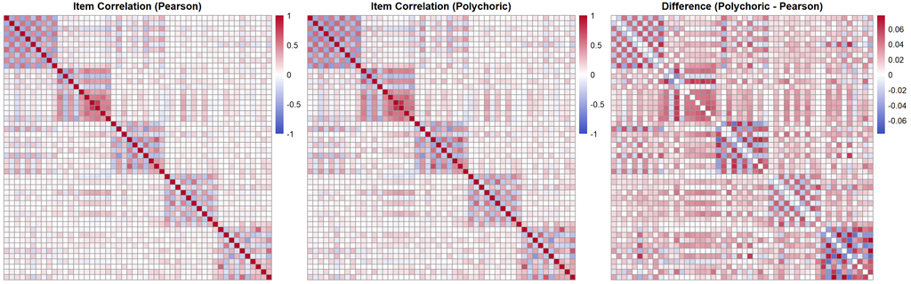

```r
pearson_mat <- cor(data_mat)


diff_item_mat <- poly_mat - pearson_mat

lim_diff <- max(abs(diff_item_mat))
breaks_diff <- seq(-lim_diff, lim_diff, length.out = 201)

p_item_pearson <- pheatmap(
  pearson_mat,
  color = coolwarm,
  breaks = breaks_full,
  cluster_rows = FALSE,
  cluster_cols = FALSE,
  main = "Item Correlation (Pearson)",
  show_rownames = FALSE,
  show_colnames = FALSE,
  silent = TRUE
)

p_item_poly <- pheatmap(
  poly_mat,
  color = coolwarm,
  breaks = breaks_full,
  cluster_rows = FALSE,
  cluster_cols = FALSE,
  main = "Item Correlation (Polychoric)",
  show_rownames = FALSE,
  show_colnames = FALSE,
  silent = TRUE
)

p_item_diff <- pheatmap(
  diff_item_mat,
  color = coolwarm,
  breaks = breaks_diff,
  cluster_rows = FALSE,
  cluster_cols = FALSE,
  main = "Difference (Polychoric - Pearson)",
  show_rownames = FALSE,
  show_colnames = FALSE,
  silent = TRUE
)

# Display the heatmaps side by side
grid.arrange(
  p_item_pearson$gtable,
  p_item_poly$gtable,
  p_item_diff$gtable,
  ncol = 3,
  widths = c(1, 1, 1)
)
```

```r
# Print a numerical summary of the differences in the console
cat("Numerical summary of the differences (Polychoric - Pearson) between items:\n")
```

```
Numerical summary of the differences (Polychoric - Pearson) between items:
```

```r
summary(as.vector(diff_item_mat))
```

```
   Min. 1st Qu.  Median    Mean 3rd Qu.    Max.
-0.0621  0.0000  0.0119  0.0124  0.0255  0.0775
```

As we have said previously, the plot clearly indicates that Pearson correlation tends to systematically underestimate the true correlation between *questions* (not factor).

# Take the Big 5 personality test

You do not need to run all the code above to run this test. You only need to run the cells before the factor analysis part and the first cell from alternative B in order to take this test.

For more worked out tests you can go to the [psytests.org](https://psytests.org/big5/ineoBen.html) website for 120 and 300 item questionnaires. It includes facets scores, which are essentially subfactors of the Big 5 factors. For example the six facet of openness are active imagination (fantasy), aesthetic sensitivity, attentiveness to inner feelings, preference for variety (adventurousness), intellectual curiosity, and challenging authority (psychological liberalism).

Run this chunk interactively in your R console to answer the 50 IPIP questions. Your Big 5 traits will be based on the previous EFA with oblique rotation (for more realism and better interpretability), minres method and polychoric correlation matrix.

Rate each statement from 1 (Disagree) to 5 (Agree).

```r
questions <- c(
  EXT1="I am the life of the party.", EXT2="I don't talk a lot.",
  EXT3="I feel comfortable around people.", EXT4="I keep in the background.",
  EXT5="I start conversations.", EXT6="I have little to say.",
  EXT7="I talk to a lot of different people at parties.", EXT8="I don't like to draw attention to myself.",
  EXT9="I don't mind being the center of attention.", EXT10="I am quiet around strangers.",

  EST1="I get stressed out easily.", EST2="I am relaxed most of the time.",
  EST3="I worry about things.", EST4="I seldom feel blue.",
  EST5="I am easily disturbed.", EST6="I get upset easily.",
  EST7="I change my mood a lot.", EST8="I have frequent mood swings.",
  EST9="I get irritated easily.", EST10="I often feel blue.",

  AGR1="I feel little concern for others.", AGR2="I am interested in people.",
  AGR3="I insult people.", AGR4="I sympathize with others' feelings.",
  AGR5="I am not interested in other people's problems.", AGR6="I have a soft heart.",
  AGR7="I am not really interested in others.", AGR8="I take time out for others.",
  AGR9="I feel others' emotions.", AGR10="I make people feel at ease.",

  CSN1="I am always prepared.", CSN2="I leave my belongings around.",
  CSN3="I pay attention to details.", CSN4="I make a mess of things.",
  CSN5="I get chores done right away.", CSN6="I often forget to put things back in their proper place.",
  CSN7="I like order.", CSN8="I shirk my duties.",
  CSN9="I follow a schedule.", CSN10="I am exacting in my work.",

  OPN1="I have a rich vocabulary.", OPN2="I have difficulty understanding abstract ideas.",
  OPN3="I have a vivid imagination.", OPN4="I am not interested in abstract ideas.",
  OPN5="I have excellent ideas.", OPN6="I do not have a good imagination.",
  OPN7="I am quick to understand things.", OPN8="I use difficult words.",
  OPN9="I spend time reflecting on things.", OPN10="I am full of ideas."
)

my_answers <- numeric(length(questions))
names(my_answers) <- names(questions)

questions_order <- c(sapply(1:10, function(x) seq(x, 50, by = 10))) #shuffle questions
# Interactive prompt loop1
for (i in questions_order) {
  valid <- FALSE
  while (!valid) {
    ans <- readline(prompt = paste0(questions[i], " [1-5]: "))
    ans_num <- as.numeric(ans)

    if (!is.na(ans_num) && ans_num >= 1 && ans_num <= 5 && ans_num %% 1 == 0) {
      my_answers[i] <- ans_num
      valid <- TRUE
    } else {
      cat("Invalid input. Please enter an integer between 1 and 5.\n")
    }
  }
}

my_answers <- my_answers[colnames(data_mat)]

# Standardize and calculate factor scores
pop_means <- colMeans(data_mat)
pop_sds   <- apply(data_mat, 2, sd)
my_answers_std <- (my_answers - pop_means) / pop_sds

my_scores <- as.numeric(t(my_answers_std) %*% fa_obli$weights)
my_scores <- my_scores[c(1, 2, 3, 5, 4)]
names(my_scores) <- trait_names

# Calculate percentiles based on the original distribution
my_percentiles <- sapply(trait_names, function(t) {
  ecdf(data_fa_obli[[t]])(my_scores[t])
})

results <- data.frame(
  Factor_Score = round(my_scores, 3),
  Percentile = paste0(round(my_percentiles * 100, 1), " %")
)

print(results)
```